# Introduction to Network Science

Core concepts

Szymon Talaga http://iss.uw.edu.pl/szymon-talaga (Robert Zajonc Institute for Social Studies, University of Warsaw)http://iss.uw.edu.pl  
October 15, 2021

```r
ROOT <- here::here()
DATA <- file.path(ROOT, "data")
UTIL <- file.path(ROOT, "scripts")

source(file.path(UTIL, "prep-dependencies.R"))

knitr::opts_chunk$set(
    echo = TRUE,
    fig.width = 8,
    fig.height = 5
)

# PACKAGE THAT WE WILL USE
library(tidyverse)
library(ggplot2)
library(ggforce)
library(igraph)
library(ggraph)
library(latex2exp)

# SET DEFAULT AETHETICS FOR `ggplot2`
theme_set(theme_bw())
```

# Introduction

In this notebook we will get some hands-on experience with basic, core notions of network science as well as working with one of the major network libraries for `R`, which is the `igraph` package. `Igraph` is a very powerful and efficient library and will do very well for our purposes. However, there are some alternatives such as [statnet suite of packages](http://statnet.org/) which is also very popular among social scientist. However, due to time constraints we have to choose one and `igraph` will be our choice for this class.

In this practice session we will learn about:

1. Loading graph datasets into working memory.
2. Adding vertex and edge attributes to graph objects.
3. Calculating edge densities and degree distributions.
4. Drawing graphs using `ggraph` library which works on top of the excellent `ggplot2` library.
5. Sampling from simple generative models, namely ER random graph model and it is simple extension known as stochastic block model.
6. Along the way we will try to answer some questions which may be interesting for social scientists.
7. And work with some fundamental programming abstractions such as loops and map procedures.

## Datasets

In this class in general we will work primarily with the following three real-world networks:

1. **Hyperlinks between US political blogs in 2004.** This is a quite famous dataset representing hyperlink connections between various US political blogs in 2004. Crucially, it also provides information on general political affiliations of the blogs (i.e. republican vs democrat). As such it is a perfect dataset for studying, for instance, homophily and reciprocity in politics-focused mass online communication. It may not be a typical elite network but it gives some interesting snapshot of public discourse concerning political elites. Moreover, it can be argued that some of the most influential bloggers can be considered a part political elites due to the potential for influencing decision-makers and voters alike.
   - It is a directed network with $1490$ nodes and $19090$ so it is relatively large.
2. **Conflict-induced decomposition of a karate club in 1970’s (US).** This is clearly not an elite network, but it is very famous in network science and we will use it to discuss several methods, particularly community detection. It represents associations (e.g. frequent talking outside the class) between members of a karate club in 1970’s in the US, as measured through an in-depth ethnographic observations, in the period when the club had been going through a serious conflict between the main instructor and the main administrator, leading to a decomposition into two opposing camps.
   - It is an undirected network with $34$ nodes and $78$ edges. It comes with edge weights, but very often is analyzed also as an unweighted network.
3. **Association within Mexican political elites in XX century.** It depicts associations — through political, kinship, friendship and business ties — between some of the leading members of Mexican political elites throughout the XX century. It includes metadata indicating whether a given person is of a civilian or military status as well as the year of joining the government. I also extended the metadata for our purposes by adding years of death as well as the number of years of functioning within the elite (the number of years before joining the government and dying or the year of publication of the study which is 1996).
   - It is an undirected network with $35$ nodes and $117$ edges. Note that thanks to time-related metadata it can be also seen as a dynamic network evolving through time. We will try to study it also from this perspective.

All the datasets are already prepared and available in `data` subdirectory. They are saved in the so-called `GML` (Graph Modeling Language) format which is one of popular formats for storing graph data. The data files are also compressed using the GZIP algorithm so they need to be uncompressed first.

# Loading data

Since the data files are compressed we will start by writing a simple function for loading our datasets. Note that in the first chunk we define `DATA` global variable which is a path pointing to the `data` subdirectory.

```r
## HERE WE DEFINE THE FUNCTION FOR READING DATA
##
## NOTE THAT WE USE `datapath` ARGUMENT WITH THE DEFAULT VALUE
## EQUAL TO `DATA` GLOBAL VARIABLE.
## THIS WAY THE FUNCTION CAN BE USED WITHOUT SPECIFYING `datapath` ARG
## EVER TIME, BUT IT CAN BE CUSTOMIZED IF NEEDED.

read_gml <- function(name, datapath = DATA) {
    # define ungzipped connection to the file (so-called file handle)
    # note that we use `open = "rb"` argument to specify that we
    # are opening the file only for reading data and we do this
    # in so-called binary format, since the file is compressed.

    # Add extensions `.gml.gz` to `name` if needed
    if (!str_ends(name, "\\.gml\\.gz")) name <- str_c(name, ".gml.gz")
    # Define path to the particular file we want to open
    # by concatenating `name` to `datapath`.
    fpath <- file.path(datapath, name)
    # Create file handle with GZIP compression
    fh <- gzfile(fpath, open = "rb")
    # Load graph
    G <- read_graph(fh, format = "gml")
    # Return the graph
    G
}
```

# Karate club network

We start by analyzing the karate club network as it is relatively small and simple. First, we need to load it. The second obvious step in network analysis (usually) is to try to visualize your network, in particular if it is not too big, to get some feel for how it really looks. Such visual and exploratory data analysis is very often necessary for really understanding our data.

```r
# We will usually use `G` variable to refer to the main network object
# we are currently working with.
G <- read_gml("karate")
# Look at the graph
G
```

```
IGRAPH 2e9238a UNW- 34 78 --
+ attr: id (v/n), name (v/c), label (v/c), color (v/n),
| faction (v/c), weight (e/n)
+ edges from 2e9238a (vertex names):
 [1] Mr Hi  --Actor 2  Mr Hi  --Actor 3  Mr Hi  --Actor 4
 [4] Mr Hi  --Actor 5  Mr Hi  --Actor 6  Mr Hi  --Actor 7
 [7] Mr Hi  --Actor 8  Mr Hi  --Actor 9  Mr Hi  --Actor 11
[10] Mr Hi  --Actor 12 Mr Hi  --Actor 13 Mr Hi  --Actor 14
[13] Mr Hi  --Actor 18 Mr Hi  --Actor 20 Mr Hi  --Actor 22
[16] Mr Hi  --Actor 32 Actor 2--Actor 3  Actor 2--Actor 4
[19] Actor 2--Actor 8  Actor 2--Actor 14 Actor 2--Actor 18
+ ... omitted several edges
```

We see some sample edges as well as the list of attributes defined on our graph object. Most importantly, we see two vertex attributes of interest: `name` and `faction` referring to the group to which a given node belonged in the conflict between the instructor and the administrator.

For the purpose of visualization we will now add also `deg` attribute storing node degrees. This way it will be easy for us to scale node sizes according to their degrees, to easily see which nodes are most well-connected.

```r
V(G)$deg <- degree(G)
```

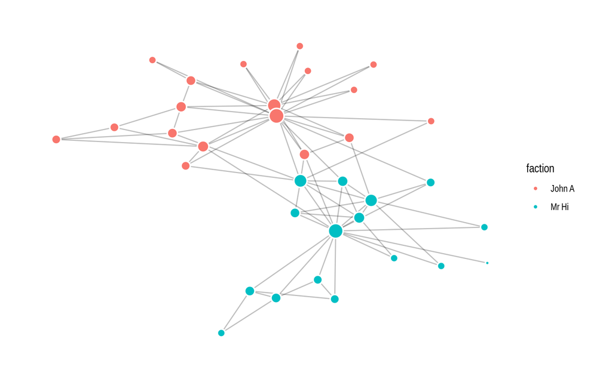

```r
# ON TOP THERE IS A MAIN CALL TO `ggraph` FUNCTION WHICH SETS UP THE CANVAS
# FOR OUT PLOT.
# THEN WE ADD SUBSEQUENT LAYER OF OUR FIGURE USING THE `+` OPERATOR.
karate_plot <- ggraph(G, layout = "fr") +
    geom_edge_link(     # HERE WE ADD LAYER DRAWING EDGES BETWEEN NODE
        alpha = .25,    # WE DO NOT CARE SO MUCH ABOUT SEEING EDGES SO WE MAKE THEM PARTIALLY TRANSPARENT
    ) +
    geom_node_point(         # LAYER DRAWING NODES AS POINTS
        aes(
            fill = faction,  # USE FACTION ATTRIBUTE TO FILL NODES WITH DIFFERENT COLORS
            size = sqrt(deg) # USE SQUARE ROOT OF NODE DEGREE TO SCALE NODE SIZES
        ),
        shape = 21L,         # A PARTICULA POINT SHAPE WHICH CAN USE SEPARATE INTERNAL AND BORDER COLORS
        color = "white",     # USE WHITE BORDERS FOR NICE VISUALIZATION
        stroke = 1,          # WIDTH OF THE BORDERS
     ) +
    # REMOVE LEGEND FOR NODE SIZE
    guides(
        size = "none"
    ) +
    # ADD GRAPH SPECIFIC AESTHETIC THEME
    theme_graph()

# WE SAVED THE PLOT AS VARIABLE
# SO WE CAN MODIFY IT LATER
karate_plot
```

We know that the dynamics of the group were driven by the two main actors — the main instructor (known as Mr Hi) and the main administrator (known as John A). So it may be worthwhile to see where they are in the network. Thus, we will now add node labels to the picture.

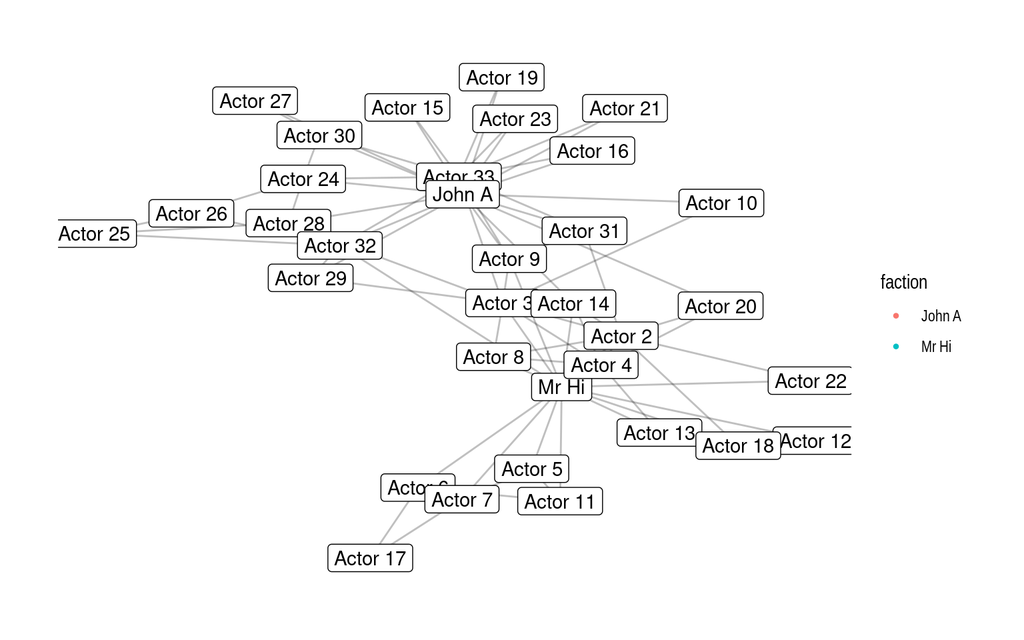

```r
karate_plot +
    geom_node_label(aes(label = name))
```

It does not look very good, because the plot is cluttered with *names* of less important actors. So it is better to plot only Mr Hi and John A. To do so, we can transform `name` variable within our call to `geom_node_label` so only Mr Hi and John A are shown.

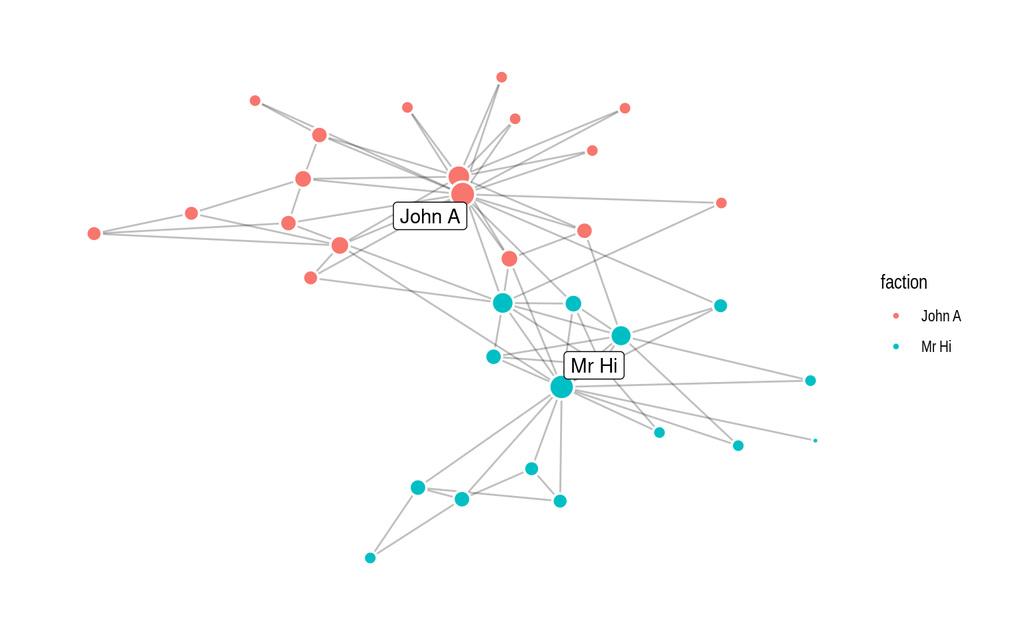

```r
karate_plot +
    geom_node_label(aes(
        label = ifelse(name %in% c("Mr Hi", "John A"), name, NA_character_)
    ), repel = TRUE)
```

We can now see that, indeed, the two man are central nodes in their corresponding factions.

## Edge density and degree distribution

Let us now try to summarize our network somehow in more quantitative terms. We will use the two main properties we learned about during the lecture, that is, edge density and degree distribution.

```r
edge_density(G)
```

```
[1] 0.1390374
```

We see that about $14\%$ of all possible edges exist in the network. Whether this fraction is high or small depends very much on the context, so we will not interpret it in this terms right now. However, knowing edge density is sometimes very important as we will learn later. But for now, let us just be happy that we managed to calculate it.

Now we turn to the degree distribution of our network. As we will see it very much **not Poissonian** pointing to the fact that real networks are hardly ever similar to ER random graphs in this respect.

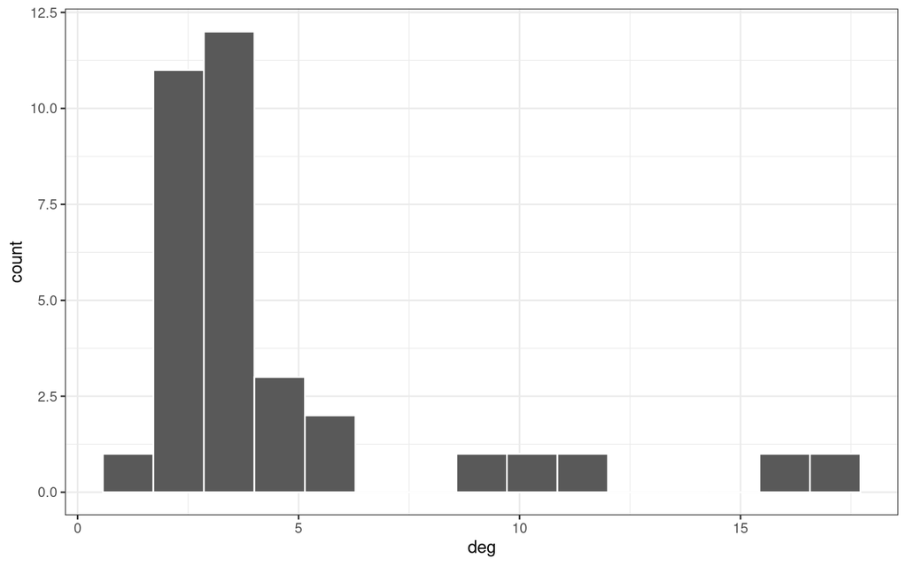

```r
## CREATE A SIMPLE DATA FRAME WITH NODE DEGREES
data <- tibble(deg = degree(G))

## DRAW HISTOGRAM
ggplot(data) +
    geom_histogram(
        aes(x = deg),
        bins = 15L,
        color = "white"
    )
```

Clearly, the distribution has a long tail of large values. These are hubs of the networks, that is, most central nodes. To see how far off this is from the Poisson distribution expected for ER random graphs we can overlay the plot with expected degree probabilities for a Poisson distribution with the same average degree.

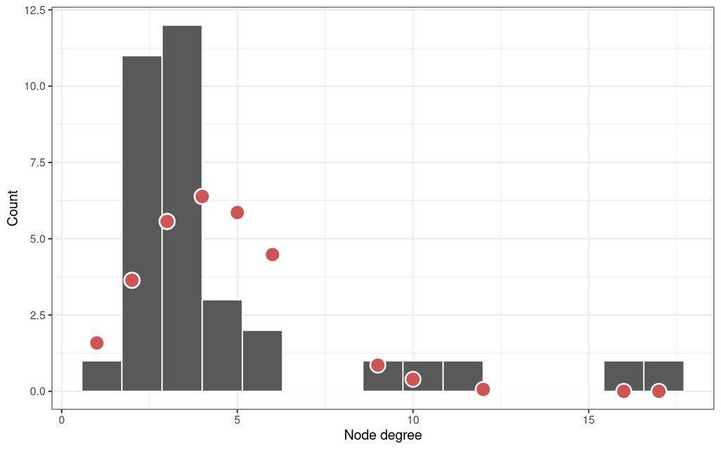

```r
# CALCUALTe AVERAGE DEGREE
dbar <- mean(degree(G))

## CREATE A SIMPLE DATA FRAME WITH NODE DEGREES
## AND POISSONIAN PROBABILITIES
data <- tibble(
    deg = degree(G),
    p   = dpois(deg, lambda = dbar),
    n   = p * vcount(G)   # Expected number of nodes of a given degree given Poisson dist
)

## DRAW HISTOGRAM
ggplot(data) +
    geom_histogram(
        aes(x = deg),
        bins = 15L,
        color = "white"
    ) +
    geom_point(aes(x = deg, y = n), shape = 21L, fill = "indianred3", color = "white", stroke = 1, size = 5) +
    labs(
        x = "Node degree",
        y = "Count"
    )
```

### Comparison with ER model ensemble

Okay, but maybe the distribution is really like in ER random graph and it is so right-skewed only because of a particular combination of edge density and size of the network? That may be, so let us check this. We will now use one of the most fundamental techniques of computational network science (even though in a very simple manner).

We will simulate a large number of ER random graphs with the same edge density as our observed network and use this large ensemble of simulated network to calculate a sort of expected distribution. This large set of simulated networks will form our **null distribution** for the degree distribution assuming that the generative model for our network was really just an ER random graph model. And if our observed network is very unlikely relative to our assumed null distribution then we can conclude that its degree distribution cannot be really explained by ER random graph model.

**NOTE.** The above logic is in fact very similar to how statistical tests are constructed in classical statistics (test statistics are also calculated to some particular null distribution). The important difference in the case of network analyses like the one above, is that we need to be more careful about choosing a null distribution we want to test against. In the case of standard statistical tests there is usually a natural choice for null distribution while in the case of networks this problem is more complex. We will return to this point later on.

```r
N <- 100L   # Number of simulated networks
density <- edge_density(G)
n_nodes <- vcount(G)

simulated <- vector(mode = "list", length = N)
for (i in 1:N) {
    er_graph <- sample_gnp(n_nodes, p = density, directed = FALSE)
    df <- tibble(deg = degree(er_graph))
    simulated[[i]] <- df
}

# Combine simualted data frames into a single data frame
# and count occurences of node degres
simulated <- bind_rows(simulated) %>%
    group_by(deg) %>%
    tally() %>%    # Calculate counts
    mutate(
        p = n / sum(n),
        mode = "simulated"
    )

simulated
```

```
# A tibble: 13 × 4
     deg     n        p mode
   <dbl> <int>    <dbl> <chr>
 1     0    23 0.00676  simulated
 2     1   139 0.0409   simulated
 3     2   300 0.0882   simulated
 4     3   520 0.153    simulated
 5     4   737 0.217    simulated
 6     5   661 0.194    simulated
 7     6   465 0.137    simulated
 8     7   291 0.0856   simulated
 9     8   157 0.0462   simulated
10     9    82 0.0241   simulated
11    10    18 0.00529  simulated
12    11     6 0.00176  simulated
13    13     1 0.000294 simulated
```

We can now plot observed and simulated histograms together. It is evident that ER model cannot produce the observed degree distribution. Hence, we can reject it as a generative model for our data.

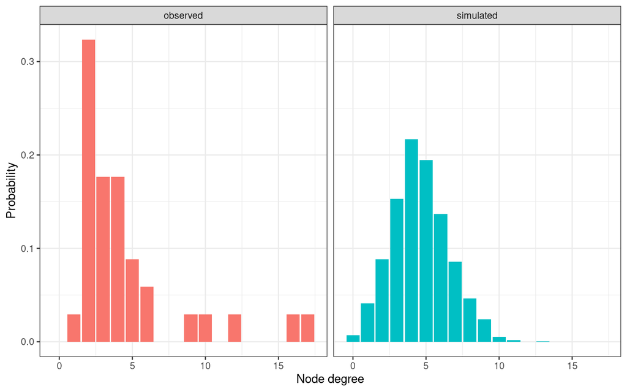

```r
observed <- tibble(deg = degree(G)) %>%
    group_by(deg) %>%
    tally() %>%
    mutate(
        p = n / sum(n),
        mode = "observed"
    )

data <- bind_rows(observed, simulated)

ggplot(data) +
    geom_bar(aes(x = deg, y = p, fill = mode), stat = "identity", show.legend = FALSE) +
    facet_wrap(~mode) +
    labs(x = "Node degree", y = "Probability")
```

# Practice problem I

Load and plot Mexican elites (`read_gml("mexican-elites")`) network. Calculate its edge density and degree distribution. Does it look like a Poisson distribution, that is, as if it was generated from ER random graph model?

# So why do we care about ER random graph model?

We have sort of shown that ER model is poor fit for many real networks. So why should we care about it? We should because:

1. It is simple and can be used to generate random networks conditioned on only a single global property: **edge density** (and number of nodes, but this is obvious and trivial).
2. It is related to small-world effect (we will discuss this later).
3. It explains the prevalence of giant components in nature. More concretely, it shows that it is enough to have a relatively low fraction of random connections to guarantee that most of the network will form one connected giant components. This is really one of the most fundamental results of early network science. We take it for granted now, but it is really important. It show that some kinds of structure arise from pure randomness. And a lot of network science is about trying to distinguish between different kinds of structures driven by different generating mechanism, some of which may be more and some less random.
4. It is basis on which other more complex generative models are built, so it is important to understand it in order to understand other models.

# Stochastic block model and the paradox of minority and majority groups

We will know introduce ourselves to a simple generalization of ER random graph model known as stochastic block model and we will use them to derive a very interesting result from quantitative sociology in the tradition of Georg Simmel and Peter Blau.

Stochastic block model is a network model in which we have $N$ nodes divided in $k$ non-overlapping groups. Then, ties between (and within) different groups have different probabilities of existence.

We will now consider a simple stochastic block model of the following specification:

$$n_1 = 100, n_2 = 10
\\
\begin{array}{c|cc}
& 1 & 2 \\
\hline
1 & .14 & \\
2 & .1, & .5
\end{array}$$
So we have a majority group composed of $100$ nodes and minority group composed of $10$ nodes. We also set connection probabilities so they satisfy the following requirements:

- Majority group ($100$ nodes) has only a slight preference for in-group ties $(.14 / .1 = 1.4)$
- Minority group ($10$ nodes) has much stronger preference for in-group ties $(.5 / .1 = 5)$
- Expected degree for members of the two groups are the same and approximately equal to $15$

So it is clear from the setup that the minority group has stronger preference for in-group ties and does not differ from the majority group in terms of average degree. However, as we will now see in terms of observed relations the minority group will have “more open” ties, meaning more out-group connections. And this results only from the relative sizes of the two groups and this simple quantitative effect is stronger that the bias we built in our model.

This is quite important as it is common for people in social science to fall in the trap of “psychological fallacy”, where they try to explain results as the one above by referring to some internal psychological properties, while very often there are much simple explanations based only on the objective quantitative structure properties of a social system at hand.

```r
n1 <- 100L      # Majority group size
n2 <- 10L       # Minority group size

pmatrix <- matrix(c(
    .14, .1,
    .1, .5
), byrow = TRUE, ncol = 2L)


# Sample single SBM realization from the above model
# We write a simple function to add block membership when generating graphs from SBM
simulate_sbm <- function(n1, n2, pmatrix) {
    N <- n1 + n2
    G <- sample_sbm(N, pref.matrix = pmatrix, block.sizes = c(n1, n2), directed = FALSE)
    block <- rep(c("I", "II"), times = c(n1, n2))
    V(G)$block <- block
    G
}
```

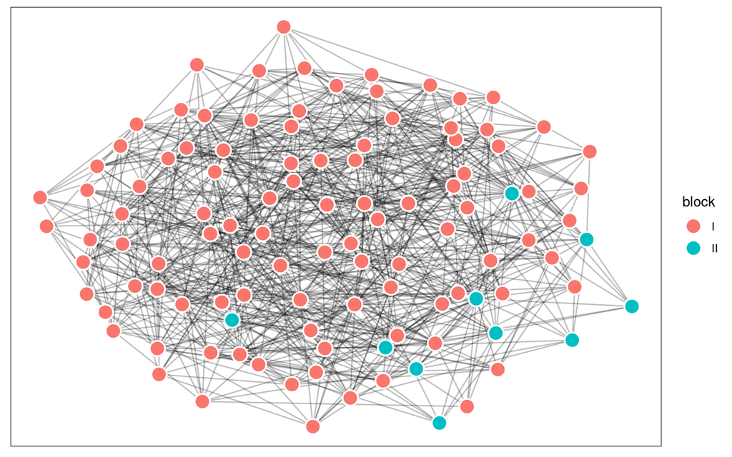

```r
set.seed(10101)

G <- simulate_sbm(n1, n2, pmatrix)

ggraph(G) +
    geom_edge_link(alpha = .25) +
    geom_node_point(aes(fill = block), shape = 21L, color = "white", stroke = 1, size = 5)
```

Now we need to calculate fraction of out-group edges per block. We can quite easily find all edges going between the two blocks and within blocks by using a special kind of syntax offered by `igraph`.

```r
## HERE WE DEFINE A FUNCTION FOR COUNTING EDGES BETWEEN TWO GROUPS OF NODES
## (WHERE THE SAME GROUP CAN BE USED TWO TIMES)
find_edges_between_groups <- function(graph, group1, group2) {
    E(graph)[group1 %--% group2]
}

# TEST FUNCTION
block1 <- V(G)[V(G)$block == "I"]
block2 <- V(G)[V(G)$block == "II"]
find_edges_between_groups(G, block1, block2)
```

```
+ 97/764 edges from 8ff1f92:
 [1] 14--101 43--101 66--101 95--101 24--102 38--102 40--102 49--102
 [9] 55--102 58--102 60--102 69--102 77--102 82--102 94--102  9--103
[17] 15--103 19--103 23--103 26--103 31--103 40--103 61--103 64--103
[25] 68--103 73--103 83--103 88--103 94--103 10--104 11--104 14--104
[33] 21--104 28--104 32--104 45--104 67--104 87--104 95--104  5--105
[41] 12--105 19--105 26--105 41--105 45--105 51--105 54--105 58--105
[49] 87--105  1--106  2--106 15--106 33--106 60--106 62--106 86--106
[57] 87--106 88--106 91--106 29--107 34--107 45--107 56--107 49--108
[65] 53--108 56--108 77--108 81--108 84--108  7--109 12--109 22--109
[73] 27--109 30--109 46--109 52--109 72--109 73--109 75--109 82--109
+ ... omitted several edges
```

```r
# Number of edges within block I
e11 <- length(find_edges_between_groups(G, block1, block1))
# Number of edges within block II
e22 <- length(find_edges_between_groups(G, block2, block2))
# Number of edges between blocks
e12 <- length(find_edges_between_groups(G, block1, block2))

# Out-group fraction in block I
out1 <- e12 / (e12 + e11)
# Out-group fraction in block II
out2 <- e12 / (e12 + e22)

c(
    "Block I"  = out1,
    "Block II" = out2
)
```

```
  Block I  Block II
0.1300268 0.8434783
```

# Practice problem II

## Part A

Simulate distribution of out-group ties fractions over $100$ replications of the above stochastic block model.

## Part B

Do the same but for many different values of probability of out-group ties ranging from $0$ and $1$ and plot your results to see how strong the in-group bias of the minority group needs to be in order to observe any empirical bias.